# Sampling requirements to detect ecosystem change

# 6 Types of sampling

1. Random
2. Regular
3. Convergent

```r
source("ar1_process.R")
```

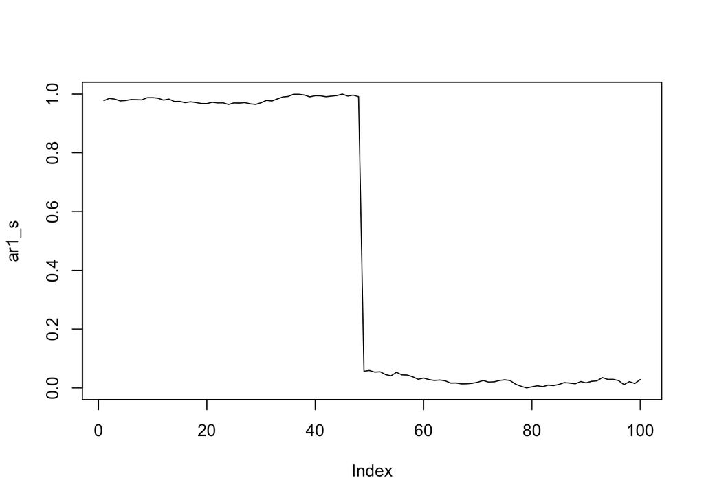

```r
source("R/uncertainty_tolerance.R")
args(ut)
```

```
## function (x = NULL, y, sample_size = NULL, type = c("mean", "sd"),
##     simulated_data = F, simulated_true_changepoint = NULL, threshold_error = 1,
##     each = 10, random_sampling = T, regular_sampling = T, convergence_sampling = T)
## NULL
```

When analysing more or less sample is easy (e.g., counting cladoceran samples vs analyzing DNA samples), can we find an optimal sampling?

Logic is a bit different, we want to know what is the minimum number of random sample we should start with, and then add samples around it to actually find the shifting point

```
## [1] "regular_cptmean"     "random_cptmean"      "convergence_cptmean"
```

|  | sample_size | threshold_error | number_sample_added | final_sample_size | cptmean | same_cptmean |
| --- | --- | --- | --- | --- | --- | --- |
| 1 | 20 | 5 | 0 | 20 | 48 | 1 |
| 2 | 21 | 5 | 0 | 21 | 46 | 1 |
| 3 | 22 | 5 | 0 | 22 | 48 | 1 |
| 4 | 23 | 5 | 0 | 23 | 46 | 1 |
| 5 | 24 | 5 | 0 | 24 | 48 | 1 |
| 6 | 25 | 5 | 0 | 25 | 46 | 1 |

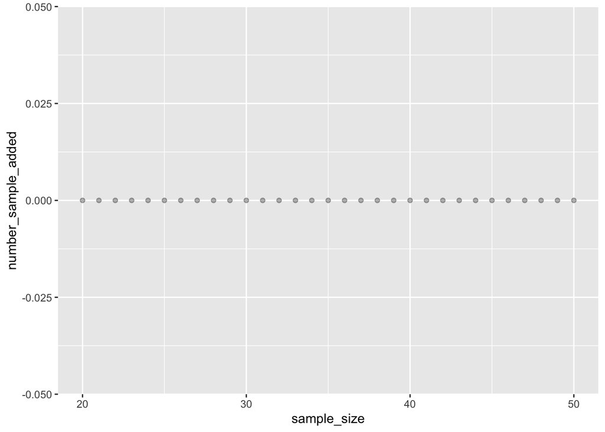

Figure 4: Adding progressively samples to fill in the gaps between transition and next/previous sample.

```
## [1] "sample_size"     "threshold_error" "cptmean"         "same_cptmean"
```

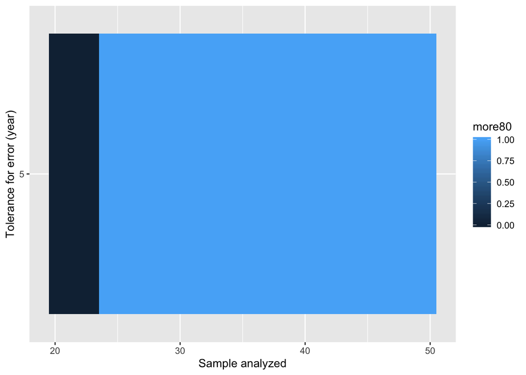

Figure 5: Dark blue: the random number of samples analyzed did not allow detection of the break